# AllDataFinalExplore

2022-06-08

#clean up and set up

```r
library(tidyverse)
```

```r
library(readr)
library(dplyr)
library(tidyr)
#df = read_csv("AllDataFinalCSV.csv")
df <- read_csv("C:/Users/kuipers/Dropbox/MAP_2022Summer/Analytics/Final Greenhouse Code/CleaningScoringData/AllDataFinalCSV.csv")
```

[output not shown]

```r
df <- df %>% mutate_all(na_if,"")


NewData = df

NewData = gather(data = df, key = PrePost, value = Score, PreTest, PostTest)

#Cornell was spelt as 'Cornel WITH AN EXTRA SPACE' is some of the rows of Institution2 so it failed some rows. Change is made below
NewData$Institution2 = ifelse(NewData$Institution2 == "Cornel  College", "Cornell College", NewData$Institution2)

NewData$InstitutionMatch = ifelse(NewData$Institution1 == NewData$Institution2, "Success", "Fail")
NewData$InstructorMatch = ifelse(NewData$Instructor1 == NewData$Instructor2, "Success", "Fail")
NewData$CourseMatch = ifelse(NewData$Course1 == NewData$Course2, "Success", "Fail")

# A few courses and instructors don't match up.

#renaming some columns

NewData = NewData %>%
  rename("att1.1" = "I would prefer to avoid courses that use statistics1","att1.2" = "Statistics will help me better understand studies that I read or hear about1", "att1.3" = "Statistics requires critical thinking that helps researchers make better decisions based upon data1", "att1.4" = "Real problems often have obstacles that could be approached in multiple ways1", "att1.5" = "This course will be useful for me in the future1", "att1.6" = "There really is no difference between statistics courses and math courses1")


NewData = NewData %>%
  rename("att2.1" = "I would prefer to avoid courses that use statistics2", "att2.2" = "Statistics will help me better understand studies that I read or hear about2", "att2.3" = "Statistics requires critical thinking that helps researchers make better decisions based upon data2", "att2.4" = "Real problems often have obstacles that could be approached in multiple ways2", "att2.5" = "This course will be useful for me in the future2", "att2.6" = "There really is no difference between statistics courses and math courses2")

NewData = NewData %>%
  rename("Response2" = "1) What is the response variable?", "EV2" = "2) What is the explanatory variable?", "DPoint2" = "3) What does each point represent?", "SlopeInc2" = "4) Would the slope increase or decrease if we removed the data point for Percent NoseBlack = 3?", "SameSlope2" = "5) Assume that in 2021 the researchers decided to collect data on a new set of lions. If they created a new plot and regression line, would you expect the value of the slope to:", "RegrLine2" = "6)  Assume that in 2021 the researchers decided to collect data on a similar set of lions from the same region. Would you expect the slope of the regression line for 2021 data to be:", "Residual2" = "7) Which of the following observed Percent NoseBlack values would have the largest positive residual?", "ModifyData2" = "8) Based on the data shown in the graph above, indicate whether you agree with each research design described below: - The researchers should consider modifying the data (such as removing the data representing Percent NoseBlack = 90) because it would create a better regression model.", "BetterModel2" = "8) Based on the data shown in the graph above, indicate whether you agree with each research design described below: - The researchers should recognize that there may be a better model to explain the patterns in their data.", "Predict2" = "8) Based on the data shown in the graph above, indicate whether you agree with each research design described below: - This graph shows that we can be confident that if Percent NoseBlack = 20, the Age will always be between 2 and 2.5.", "CorrGood2" = "8) Based on the data shown in the graph above, indicate whether you agree with each research design described below: - Since the correlation is 0.89, we can be certain that the prediction from the linear regression model would be reliable when Percent NoseBlack = 94.")

NewData = NewData %>%
  rename("Know1.1" = "Section 3:Identify your agreement with each of the following: - If a hypothesis test results in a p-value less than 0.05, we can have confidence that the test was properly conducted.", "Know1.2" = "Section 3:Identify your agreement with each of the following: - As long as we can verify that the mathematical calculations are done correctly, we can trust the statistical results....24", "Know1.3" = "Section 3:Identify your agreement with each of the following: - If the statistical conclusions align with our expectations, we can assume the data was collected appropriately.", "Know1.4" = "Section 3:Identify your agreement with each of the following: - For any real dataset, there can be multiple ways to analyze it.")

NewData = NewData %>%
  rename("Know2.1" = "Section 3:Identify your agreement with each of the following: - If a hypothesis test results in a p-value less than 0.05, we can have confidence that it was properly conducted.", "Know2.2" = "Section 3:Identify your agreement with each of the following: - As long as we can verify that the mathematical calculations are done correctly, we can trust the statistical results....65", "Know2.3" = "Section 3:Identify your agreement with each of the following: - If the statistical conclusions align with our expectations, we can assume that data was collected properly.", "Know2.4" = "Section 3:Identify your agreement with each of the following: - For any real dataset,  there can be multiple ways to analyze it.")

#removing columns with greenhouse data and blank columns
NewData = NewData[-c(67:76, 88:91)]

NewData$PrePost <- factor(NewData$PrePost, levels = c("PreTest", "PostTest"))

NewData$PriorStats1 <- factor(NewData$PriorStats1, levels = c("none", "one", "two", "three or more", "NA"))
NewData$PriorStats2 <- factor(NewData$PriorStats2, levels = c("none", "one", "two", "three or more", "NA"))


vec1 = c("White","Caucasian", "caucasian", "White (Caucasian)", "caucasion", "White/Caucasian", "Caucasian, non-Hispanic", "White/Non hispanic","white/ Caucasian", "Caucasion" , "White / Caucasian", "White (not hispanic or latino)")
NewData = mutate(NewData, Ethnicity2=ifelse(str_detect(Ethnicity2, paste(vec1, collapse = "|" )), "White", "Other"))

NewData <- NewData %>%
  mutate(Citizen2 = if_else(Citizen2 == "Yes", "Yes","No"))

NewData = mutate(NewData,Major1 = if_else(str_detect(Major1,"Gender"), "Gender", Major1))

NewData$Major1 <- tolower(NewData$Major1)

vec <- c("ecn", "econ", "stats", "nurs", "engineer", "tech", "bio", "soc", "science", "business", "health", "psych")
NewData = mutate(NewData, statsmaj=ifelse(str_detect(Major1, paste(vec, collapse = "|" )), "Yes", "No"))


NewData$Pronoun2[NewData$Pronoun2 == "He/Him/His"] <- "He"
NewData$Pronoun2[NewData$Pronoun2 == "She/Her/Hers"] <- "She"
NewData$Pronoun2[NewData$Pronoun2 == "They/Them/Theirs"] <- "Other"
NewData$Pronoun2[NewData$Pronoun2 == "Other"] <- "Other"
NewData$Pronoun2[NewData$Pronoun2 == "Prefer not to answer"] <- "Other"

NewData$Pronoun2[is.na(NewData$Pronoun2)] = "Other"
NewData$Ethnicity2[is.na(NewData$Ethnicity2)] = "Other"

# NewData$Score[is.na(NewData$Score)] = 0

###Filtering
#NewData = filter(NewData, NewData$Finished1 == "TRUE", NewData$Finished2 == "TRUE")
#dim(NewData)
###





write.csv(NewData,"NewData.csv")
```

#visualizations:

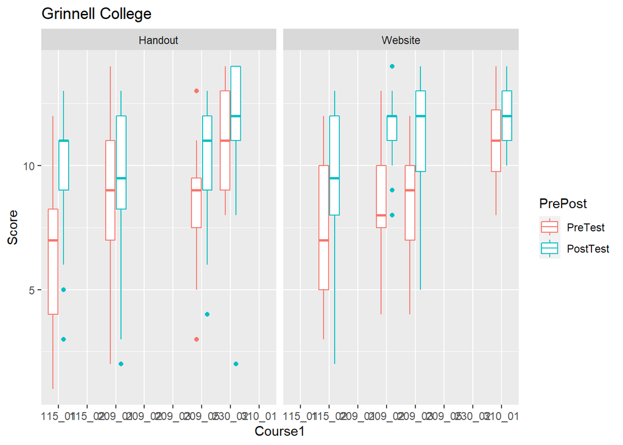

```r
#COURSES
NewData %>%
  filter(Institution1 == "Grinnell College") %>%
  ggplot(aes(x = Course1, y =Score)) + geom_boxplot() + aes(color = PrePost) +
    facet_wrap(~Type) +
    labs(title = "Grinnell College")
```

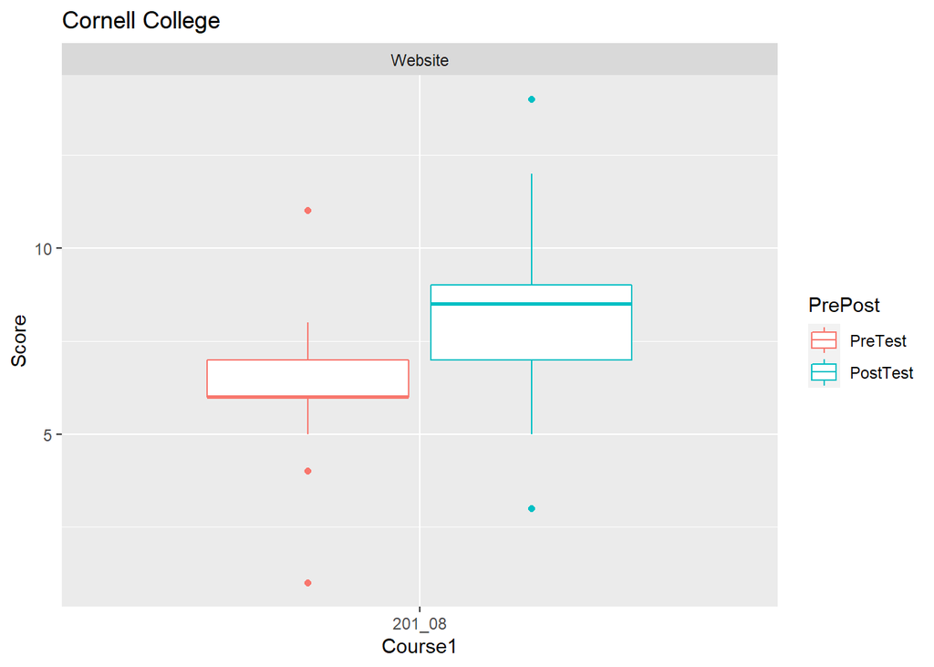

```r
NewData %>%
  filter(Institution1 == "Cornell College") %>%
  ggplot(aes(x = Course1, y =Score)) + geom_boxplot() + aes(color = PrePost) +
    facet_wrap(~Type) +
    labs(title = "Cornell College")
```

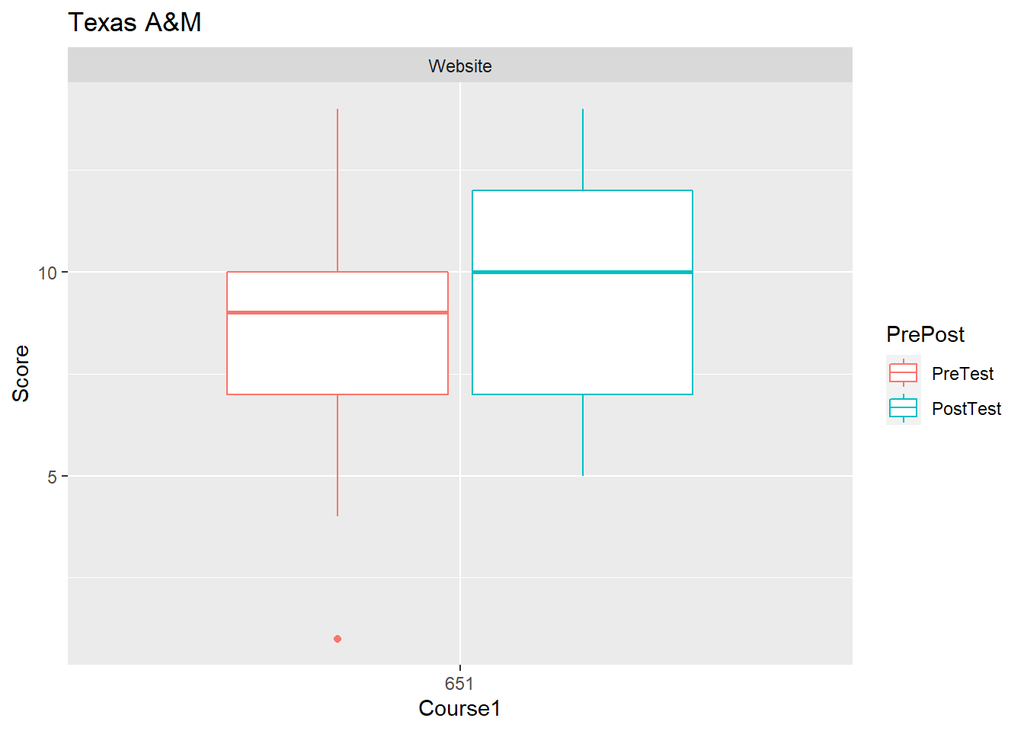

```r
NewData %>%
  filter(Institution1 == "Texas A&M") %>%
  ggplot(aes(x = Course1, y =Score)) + geom_boxplot() + aes(color = PrePost) +
    facet_wrap(~Type) +
    labs(title = "Texas A&M")
```

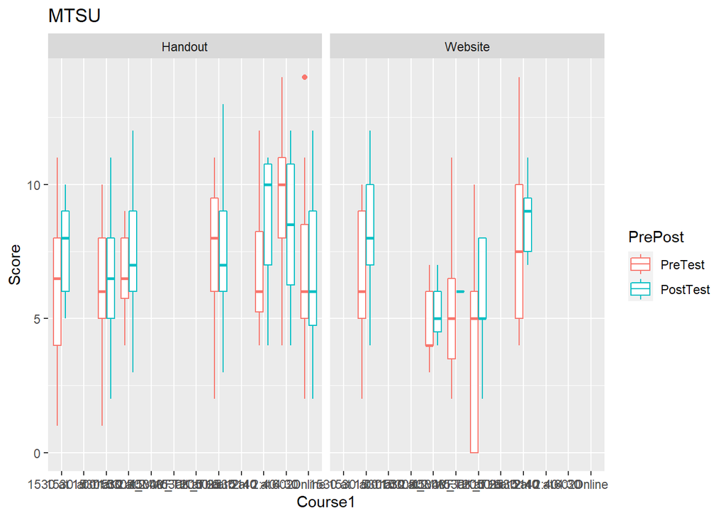

```r
NewData %>%
  filter(Institution1 == "Middle Tennessee State University") %>%
  ggplot(aes(x = Course1, y =Score)) + geom_boxplot() + aes(color = PrePost) +
    facet_wrap(~Type) +
    labs(title = "MTSU")
```

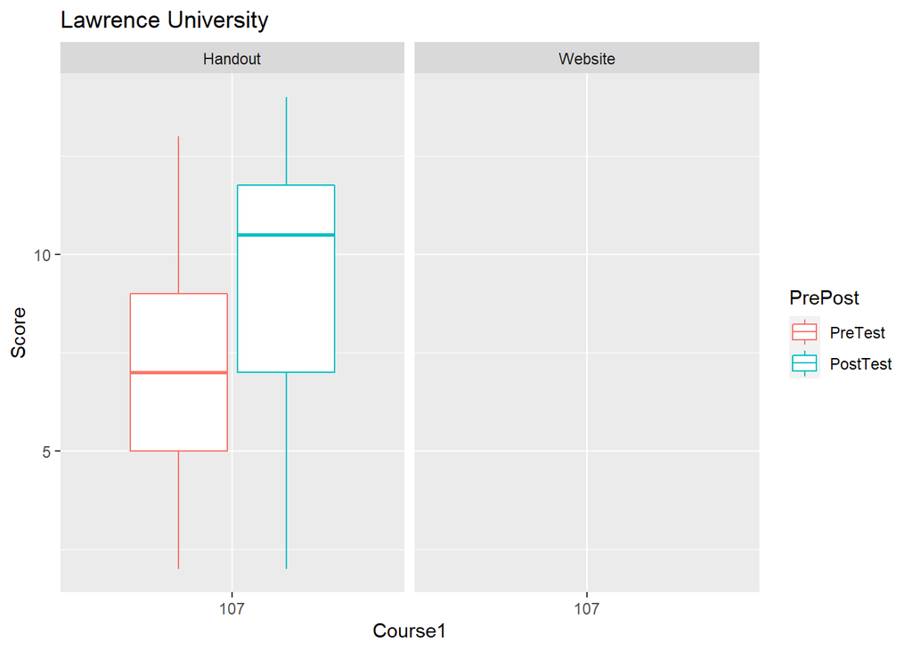

```r
NewData %>%
  filter(Institution1 == "Lawrence University") %>%
  ggplot(aes(x = Course1, y =Score)) + geom_boxplot() + aes(color = PrePost) +
    facet_wrap(~Type) +
    labs(title = "Lawrence University")
```

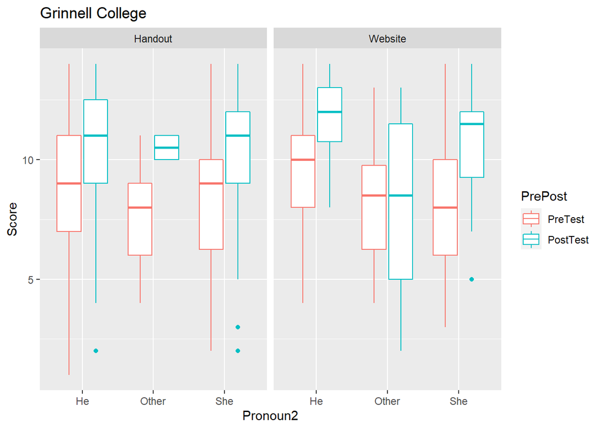

```r
#PRONOUNS

NewData %>%
  filter(Institution1 == "Grinnell College") %>%
  ggplot(aes(x = Pronoun2, y =Score)) + geom_boxplot() + aes(color = PrePost) +
    facet_wrap(~Type) +
    labs(title = "Grinnell College")
```

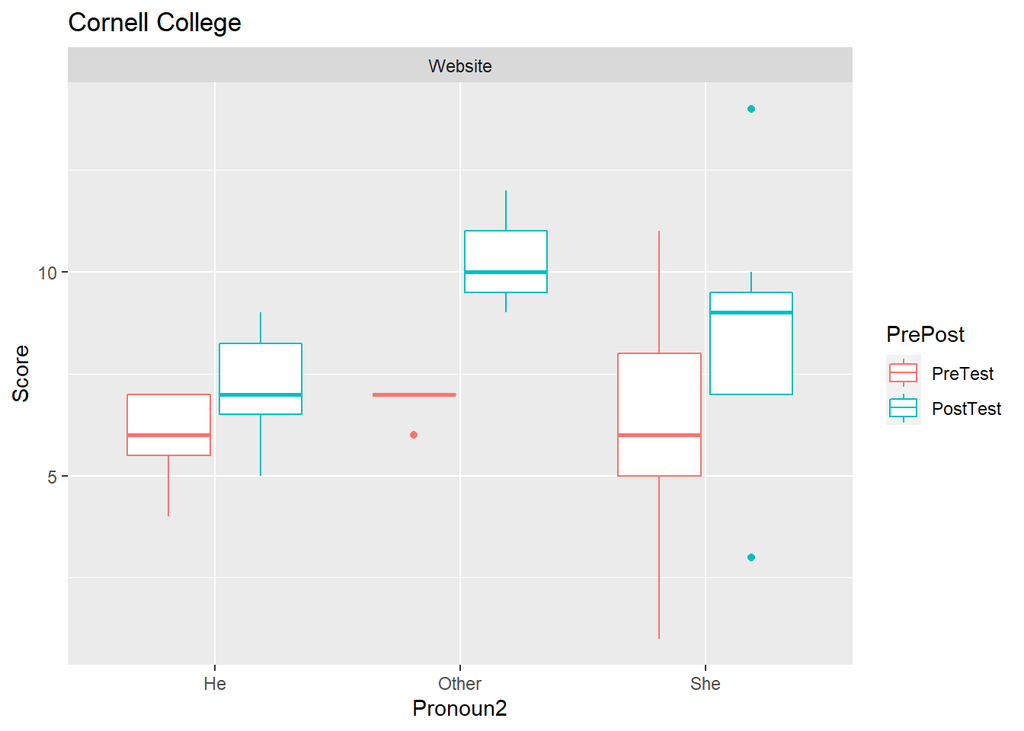

```r
NewData %>%
  filter(Institution1 == "Cornell College") %>%
  ggplot(aes(x = Pronoun2, y =Score)) + geom_boxplot() + aes(color = PrePost) +
    facet_wrap(~Type) +
    labs(title = "Cornell College")
```

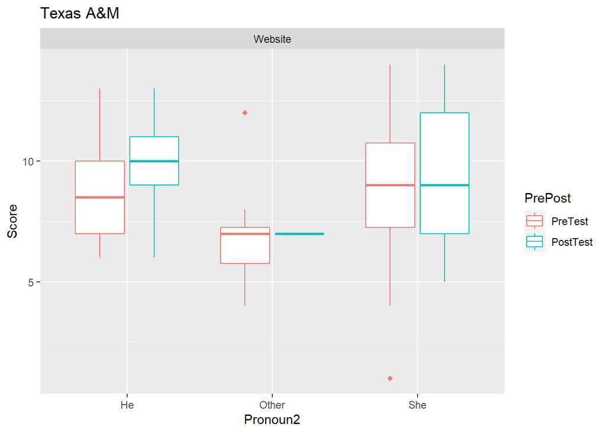

```r
NewData %>%
  filter(Institution1 == "Texas A&M") %>%
  ggplot(aes(x = Pronoun2, y =Score)) + geom_boxplot() + aes(color = PrePost) +
    facet_wrap(~Type) +
    labs(title = "Texas A&M")
```

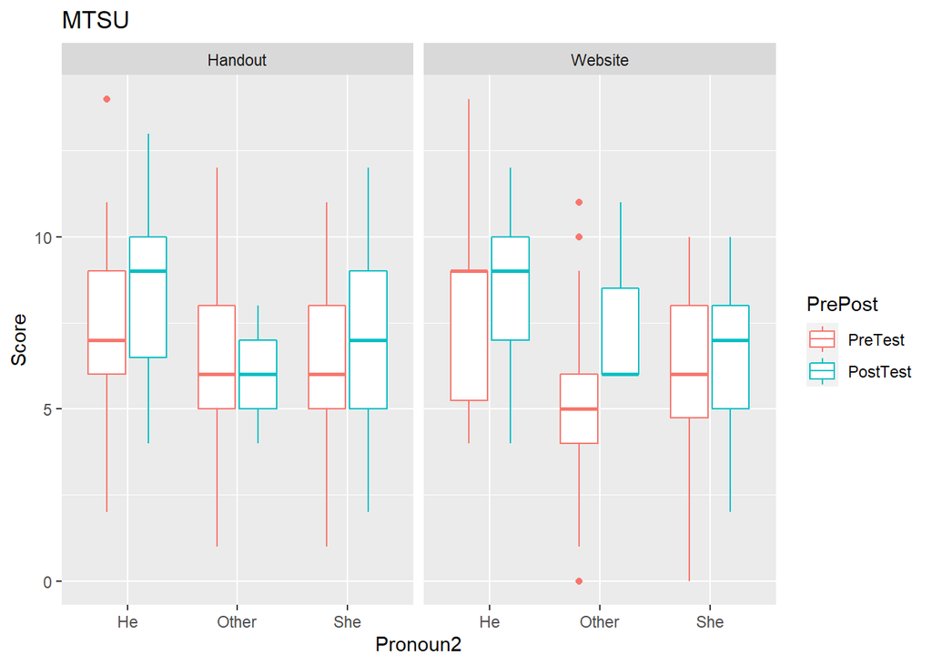

```r
NewData %>%
  filter(Institution1 == "Middle Tennessee State University") %>%
  ggplot(aes(x = Pronoun2, y =Score)) + geom_boxplot() + aes(color = PrePost) +
    facet_wrap(~Type) +
    labs(title = "MTSU")
```

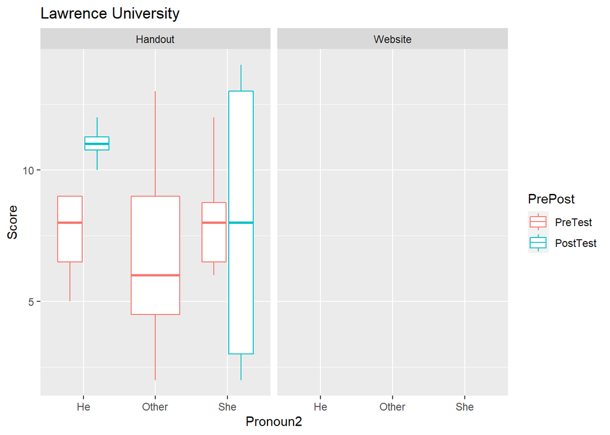

```r
NewData %>%
  filter(Institution1 == "Lawrence University") %>%
  ggplot(aes(x = Pronoun2, y =Score)) + geom_boxplot() + aes(color = PrePost) +
    facet_wrap(~Type) +
    labs(title = "Lawrence University")
```

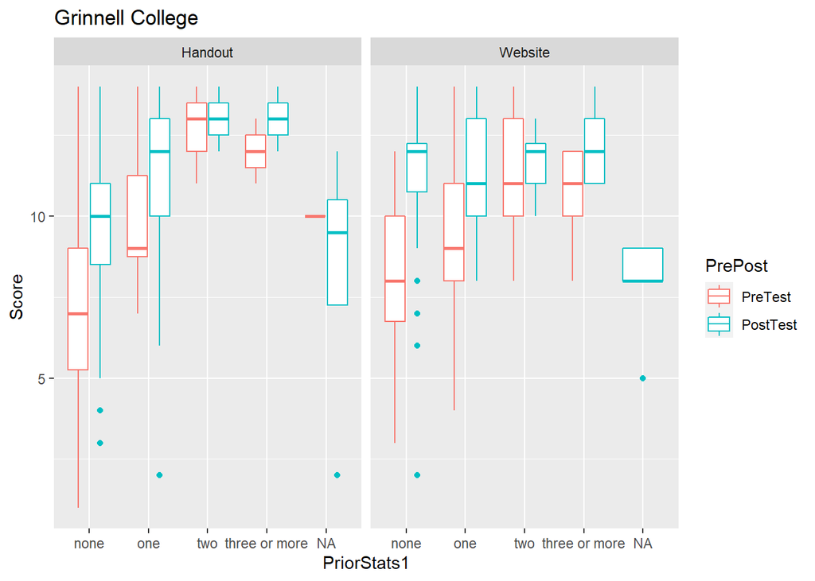

```r
#Prior Stats courses.
NewData %>%
  filter(Institution1 == "Grinnell College") %>%
  ggplot(aes(x = PriorStats1, y =Score)) + geom_boxplot() + aes(color = PrePost) +
    facet_wrap(~Type) +
    labs(title = "Grinnell College")
```

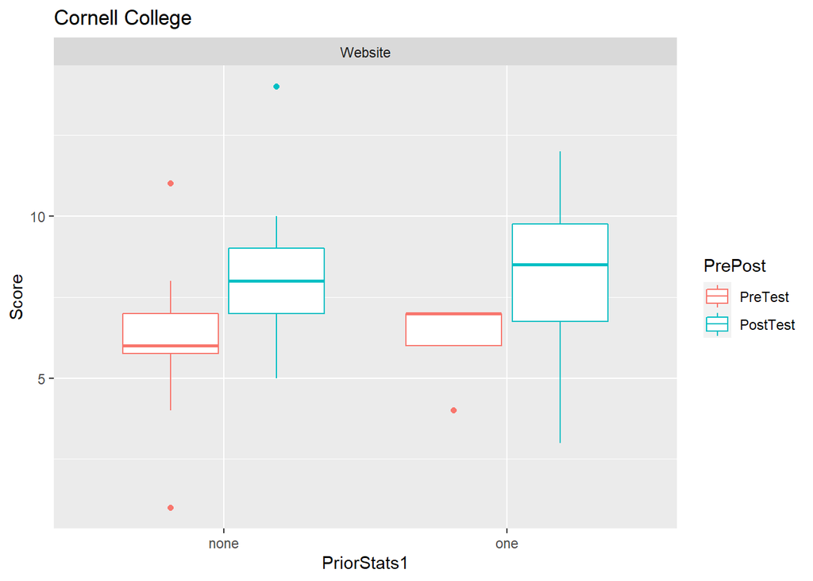

```r
NewData %>%
  filter(Institution1 == "Cornell College") %>%
  ggplot(aes(x = PriorStats1, y =Score)) + geom_boxplot() + aes(color = PrePost) +
    facet_wrap(~Type) +
    labs(title = "Cornell College")
```

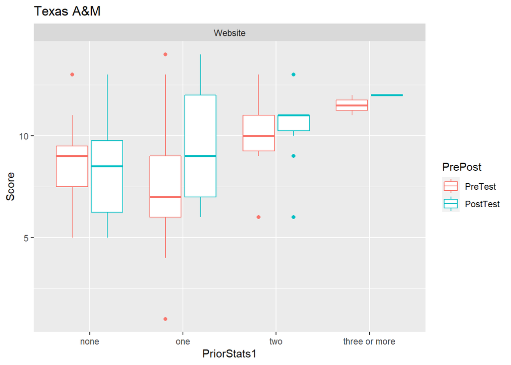

```r
NewData %>%
  filter(Institution1 == "Texas A&M") %>%
  ggplot(aes(x = PriorStats1, y =Score)) + geom_boxplot() + aes(color = PrePost) +
    facet_wrap(~Type) +
    labs(title = "Texas A&M")
```

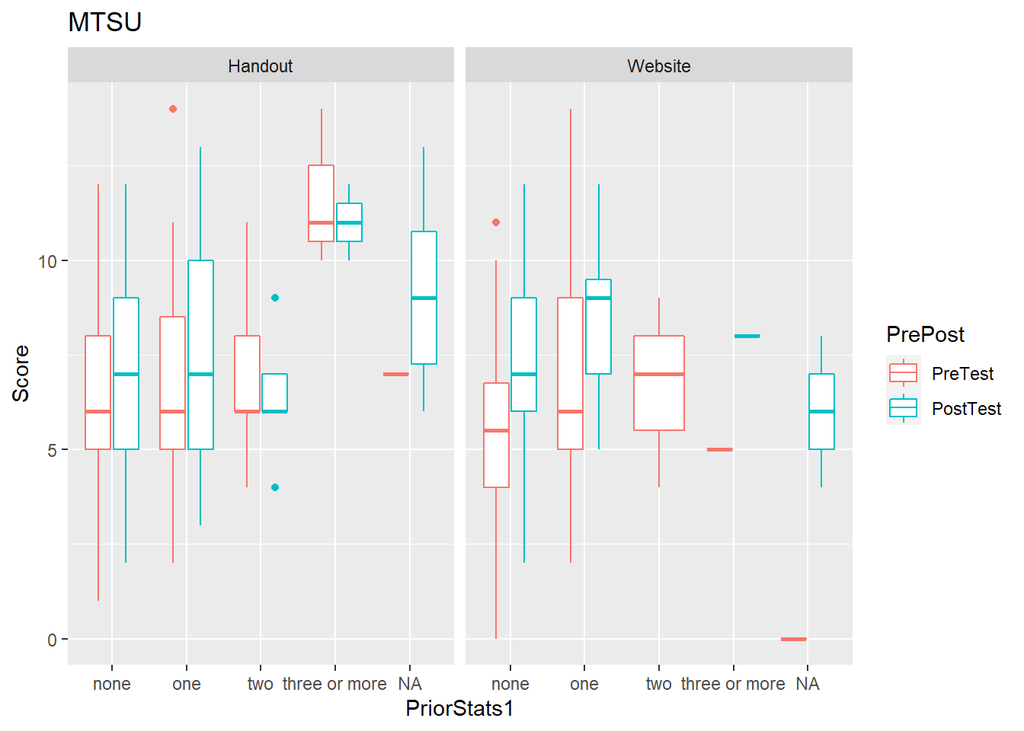

```r
NewData %>%
  filter(Institution1 == "Middle Tennessee State University") %>%
  ggplot(aes(x = PriorStats1, y =Score)) + geom_boxplot() + aes(color = PrePost) +
    facet_wrap(~Type) +
    labs(title = "MTSU")
```

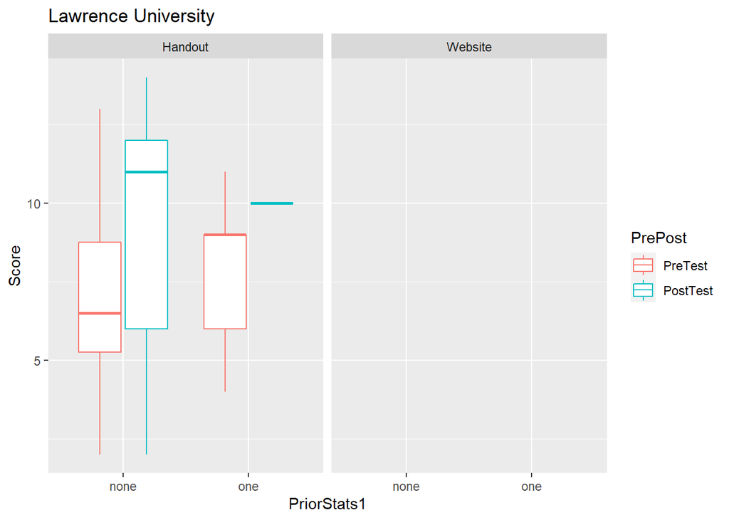

```r
NewData %>%
  filter(Institution1 == "Lawrence University") %>%
  ggplot(aes(x = PriorStats1, y =Score)) + geom_boxplot() + aes(color = PrePost) +
    facet_wrap(~Type) +
    labs(title = "Lawrence University")
```

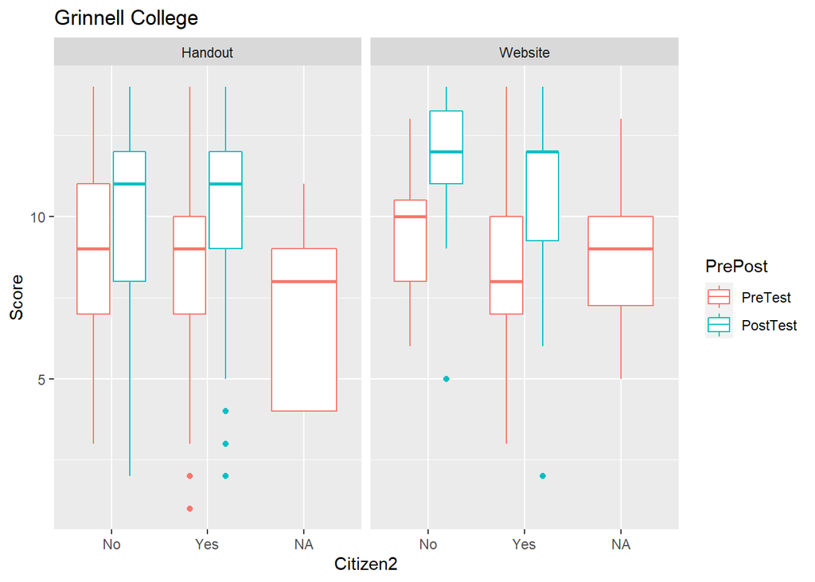

```r
#Citizen

NewData %>%
  filter(Institution1 == "Grinnell College") %>%
  ggplot(aes(x = Citizen2, y =Score)) + geom_boxplot() + aes(color = PrePost) +
    facet_wrap(~Type) +
    labs(title = "Grinnell College")
```

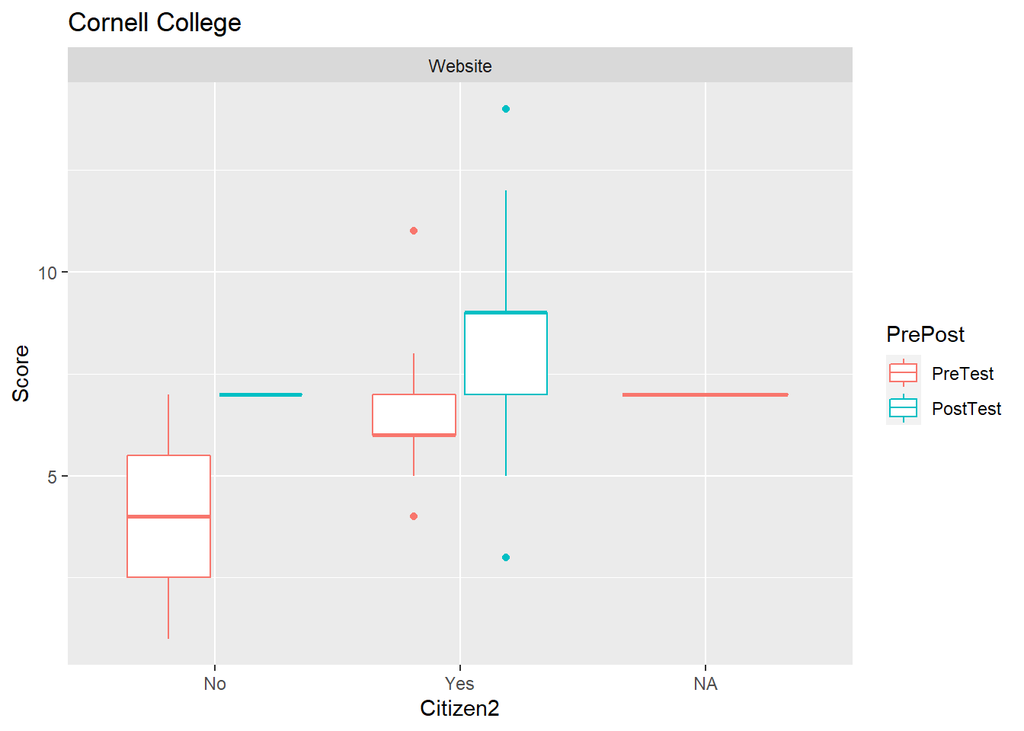

```r
NewData %>%
  filter(Institution1 == "Cornell College") %>%
  ggplot(aes(x = Citizen2, y =Score)) + geom_boxplot() + aes(color = PrePost) +
    facet_wrap(~Type) +
    labs(title = "Cornell College")
```

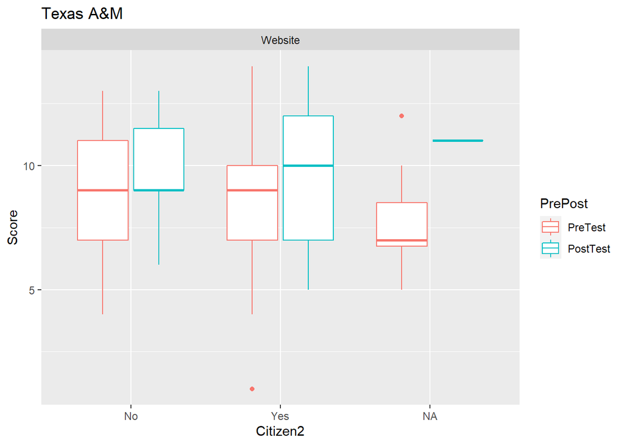

```r
NewData %>%
  filter(Institution1 == "Texas A&M") %>%
  ggplot(aes(x = Citizen2, y =Score)) + geom_boxplot() + aes(color = PrePost) +
    facet_wrap(~Type) +
    labs(title = "Texas A&M")
```

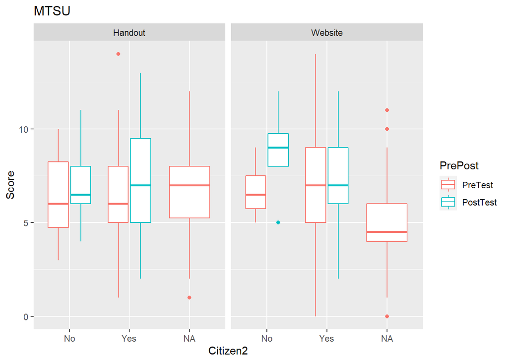

```r
NewData %>%
  filter(Institution1 == "Middle Tennessee State University") %>%
  ggplot(aes(x = Citizen2, y =Score)) + geom_boxplot() + aes(color = PrePost) +
    facet_wrap(~Type) +
    labs(title = "MTSU")
```

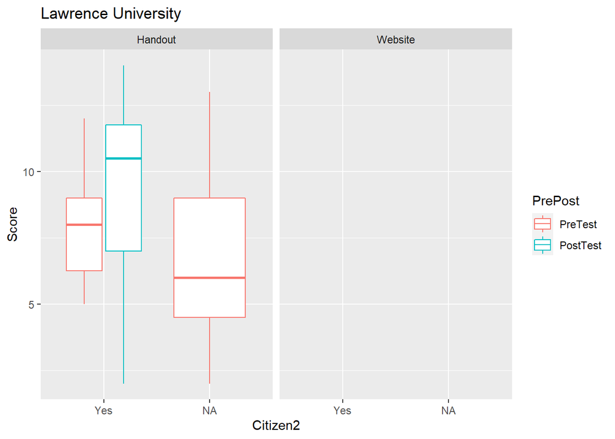

```r
NewData %>%
  filter(Institution1 == "Lawrence University") %>%
  ggplot(aes(x = Citizen2, y =Score)) + geom_boxplot() + aes(color = PrePost) +
    facet_wrap(~Type) +
    labs(title = "Lawrence University")
```

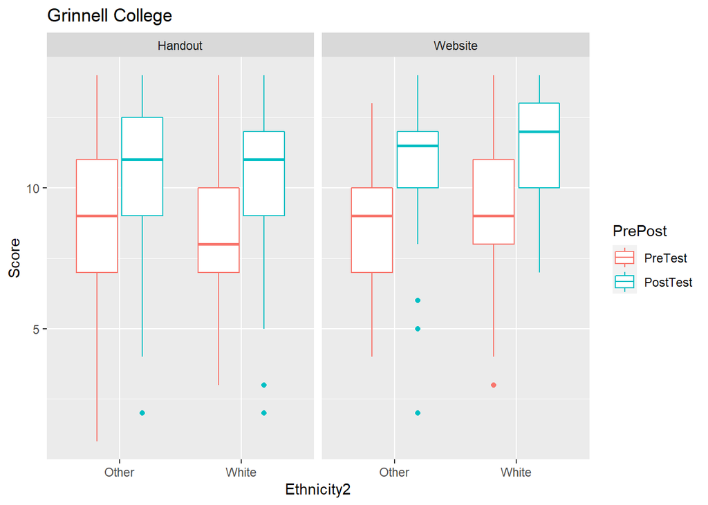

```r
#Ethnicity


NewData %>%
  filter(Institution1 == "Grinnell College") %>%
  ggplot(aes(x = Ethnicity2, y =Score)) + geom_boxplot() + aes(color = PrePost) +
    facet_wrap(~Type) +
    labs(title = "Grinnell College")
```

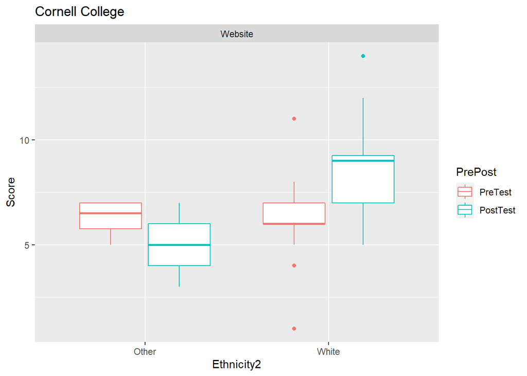

```r
NewData %>%
  filter(Institution1 == "Cornell College") %>%
  ggplot(aes(x = Ethnicity2, y =Score)) + geom_boxplot() + aes(color = PrePost) +
    facet_wrap(~Type) +
    labs(title = "Cornell College")
```

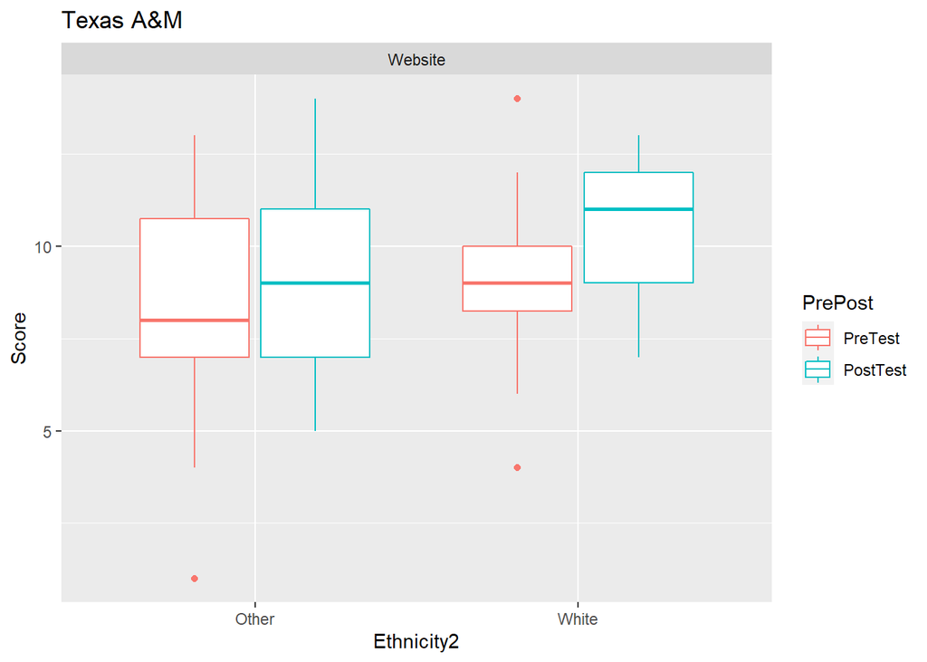

```r
NewData %>%
  filter(Institution1 == "Texas A&M") %>%
  ggplot(aes(x = Ethnicity2, y =Score)) + geom_boxplot() + aes(color = PrePost) +
    facet_wrap(~Type) +
    labs(title = "Texas A&M")
```

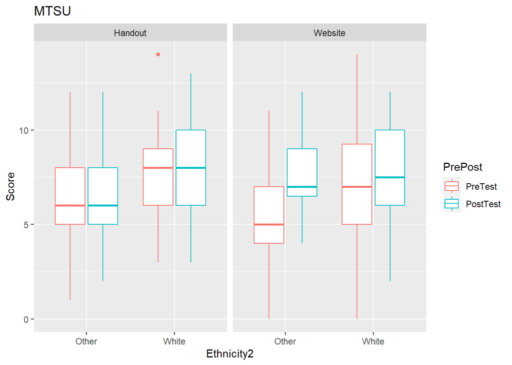

```r
NewData %>%
  filter(Institution1 == "Middle Tennessee State University") %>%
  ggplot(aes(x = Ethnicity2, y =Score)) + geom_boxplot() + aes(color = PrePost) +
    facet_wrap(~Type) +
    labs(title = "MTSU")
```

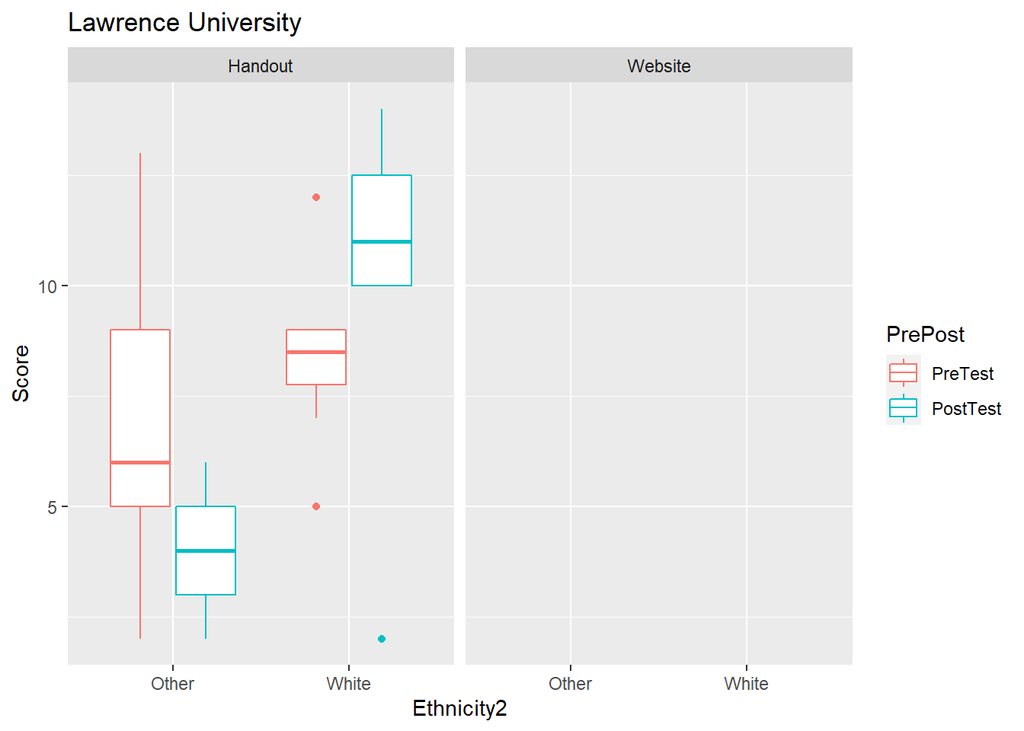

```r
NewData %>%
  filter(Institution1 == "Lawrence University") %>%
  ggplot(aes(x = Ethnicity2, y =Score)) + geom_boxplot() + aes(color = PrePost) +
    facet_wrap(~Type) +
    labs(title = "Lawrence University")
```

#optional block - all commented for now

```r
#Attitude questions
#
# NewData2 %>%
#   filter(Institution1 == "Grinnell College") %>%
#   ggplot(aes(x = Citizen2, y =Score)) + geom_boxplot() + aes(color = PrePost) +
#     facet_wrap(~Type) +
#     labs(title = "Grinnell College")
#
# ggplot(data = filter(NewData, NewData$Institution1 == "Grinnell College" & NewData$Institution2 == "Grinnell College"), aes(x = `I would prefer to avoid courses that use statistics1`, y =Score)) + geom_boxplot()  + aes(color = PrePost) + facet_wrap(~Type) + labs(title = "Grinnell College")
#
#
# ggplot(data = filter(NewData, NewData$Institution1 == "Cornell College" & NewData$Institution2 == "Cornell College"), aes(x = `I would prefer to avoid courses that use statistics1`, y =Score)) + geom_boxplot()  + aes(color = PrePost) + facet_wrap(~Type) + labs(title = "Cornell College")
#
#
# ggplot(data = filter(NewData, NewData$Institution1 == "Texas A&M" & NewData$Institution2 == "Texas A&M"), aes(x = `I would prefer to avoid courses that use statistics1`, y =Score)) + geom_boxplot()  + aes(color = PrePost) + facet_wrap(~Type) + labs(title = "Texas A&M")
#
#
# ggplot(data = filter(NewData, NewData$Institution1 == "Middle Tennessee State University" & NewData$Institution2 == "Middle Tennessee State University"), aes(x = `I would prefer to avoid courses that use statistics1`, y =Score)) + geom_boxplot()  + aes(color = PrePost) + facet_wrap(~Type) + labs(title = "Middle Tennessee State University")
#
#
# ggplot(data = filter(NewData, NewData$Institution1 == "Lawrence University" & NewData$Institution2 == "Lawrence University"), aes(x = `I would prefer to avoid courses that use statistics1`, y =Score)) + geom_boxplot()  + aes(color = PrePost) + facet_wrap(~Type) + labs(title = "Lawrence University")
```

#SCORE CALCULATIONS #background score:

```r
#Background1 questions

NewData$PriorStats1 = ifelse(NewData$PriorStats1 == "one", 1, ifelse(NewData$PriorStats1 == "two", 2, ifelse(NewData$PriorStats1 == "three or more", 3, 0)))
NewData$PriorStats1[is.na(NewData$PriorStats1)] = 0


NewData$CalcMean1[is.na(NewData$CalcMean1)] = 0
NewData$CalcMean1 = ifelse(NewData$CalcMean1 == "Yes", 1, 0)

NewData$CalcSD1[is.na(NewData$CalcSD1)] = 0
NewData$CalcSD1 = ifelse(NewData$CalcSD1 == "Yes", 1, 0)

NewData$CalcSlope1[is.na(NewData$CalcSlope1)] = 0
NewData$CalcSlope1 = ifelse(NewData$CalcSlope1 == "Yes", 1, 0)

NewData$CalcPValue1[is.na(NewData$CalcPValue1)] = 0
NewData$CalcPValue1 = ifelse(NewData$CalcPValue1 == "Yes", 1, 0)

NewData$Background1 = NewData$PriorStats1 + NewData$CalcMean1 + NewData$CalcSD1 + NewData$CalcSlope1 + NewData$CalcPValue1
```

#attitude score:

```r
#Attitude questions
NewData$att1.1[NewData$att1.1 == "Somewhat disagree"] = "Disagree"
NewData$att1.1[NewData$att1.1 == "Strongly disagree"] = "Disagree"
NewData$att1.1[NewData$att1.1 == "Somewhat agree"] = "Agree"
NewData$att1.1[NewData$att1.1 == "Strongly agree"] = "Agree"

NewData$att1.2[NewData$att1.2 == "Somewhat disagree"] = "Disagree"
NewData$att1.2[NewData$att1.2 == "Strongly disagree"] = "Disagree"
NewData$att1.2[NewData$att1.2 == "Somewhat agree"] = "Agree"
NewData$att1.2[NewData$att1.2 == "Strongly agree"] = "Agree"

NewData$att1.3[NewData$att1.3 == "Somewhat disagree"] = "Disagree"
NewData$att1.3[NewData$att1.3 == "Strongly disagree"] = "Disagree"
NewData$att1.3[NewData$att1.3 == "Somewhat agree"] = "Agree"
NewData$att1.3[NewData$att1.3 == "Strongly agree"] = "Agree"

NewData$att1.4[NewData$att1.4 == "Somewhat disagree"] = "Disagree"
NewData$att1.4[NewData$att1.4 == "Strongly disagree"] = "Disagree"
NewData$att1.4[NewData$att1.4 == "Somewhat agree"] = "Agree"
NewData$att1.4[NewData$att1.4 == "Strongly agree"] = "Agree"

NewData$att1.5[NewData$att1.5 == "Somewhat disagree"] = "Disagree"
NewData$att1.5[NewData$att1.5 == "Strongly disagree"] = "Disagree"
NewData$att1.5[NewData$att1.5 == "Somewhat agree"] = "Agree"
NewData$att1.5[NewData$att1.5 == "Strongly agree"] = "Agree"

NewData$att1.6[NewData$att1.6 == "Somewhat disagree"] = "Disagree"
NewData$att1.6[NewData$att1.6 == "Strongly disagree"] = "Disagree"
NewData$att1.6[NewData$att1.6 == "Somewhat agree"] = "Agree"
NewData$att1.6[NewData$att1.6 == "Strongly agree"] = "Agree"

NewData$att2.1[NewData$att2.1 == "Somewhat disagree"] = "Strongly disagree"
NewData$att2.1[NewData$att2.1 == "Somewhat agree"] = "Strongly agree"

NewData$att2.2[NewData$att2.2 == "Somewhat disagree"] = "Strongly disagree"
NewData$att2.2[NewData$att2.2 == "Somewhat agree"] = "Strongly agree"

NewData$att2.3[NewData$att2.3 == "Somewhat disagree"] = "Strongly disagree"
NewData$att2.3[NewData$att2.3 == "Somewhat agree"] = "Strongly agree"

NewData$att2.4[NewData$att2.4 == "Somewhat disagree"] = "Strongly disagree"
NewData$att2.4[NewData$att2.4 == "Somewhat agree"] = "Strongly agree"

NewData$att2.5[NewData$att2.5 == "Somewhat disagree"] = "Strongly disagree"
NewData$att2.5[NewData$att2.5 == "Somewhat agree"] = "Strongly agree"

NewData$att2.6[NewData$att2.6 == "Somewhat disagree"] = "Strongly disagree"
NewData$att2.6[NewData$att2.6 == "Somewhat agree"] = "Strongly agree"

NewData$att1.1[is.na(NewData$att1.1)] = 0
NewData$att1.1 = ifelse(NewData$att1.1 == "Disagree", 1, ifelse(NewData$att1.1 == "Agree", -1,0))

NewData$att1.2[is.na(NewData$att1.2)] = 0
NewData$att1.2 = ifelse(NewData$att1.2 == "Disagree", -1, ifelse(NewData$att1.2 == "Agree", 1,0))

NewData$att1.3[is.na(NewData$att1.3)] = 0
NewData$att1.3 = ifelse(NewData$att1.3 == "Disagree", 1, ifelse(NewData$att1.3 == "Agree", -1,0))

NewData$att1.4[is.na(NewData$att1.4)] = 0
NewData$att1.4 = ifelse(NewData$att1.4 == "Disagree", -1, ifelse(NewData$att1.4 == "Agree", 1,0))

NewData$att1.5[is.na(NewData$att1.5)] = 0
NewData$att1.5 = ifelse(NewData$att1.5 == "Disagree", -1, ifelse(NewData$att1.5 == "Agree", 1,0))

NewData$att1.6[is.na(NewData$att1.6)] = 0
NewData$att1.6 = ifelse(NewData$att1.6 == "Disagree", 1, ifelse(NewData$att1.6 == "Agree", -1,0))

NewData$Attd1 = NewData$att1.1 + NewData$att1.2 + NewData$att1.3 + NewData$att1.4 + NewData$att1.5 + NewData$att1.6

NewData$att2.1[is.na(NewData$att2.1)] = 0
NewData$att2.1 = ifelse(NewData$att2.1 == "Strongly disagree", 1, ifelse(NewData$att2.1 == "Strongly agree", -1,0))

NewData$att2.2[is.na(NewData$att2.2)] = 0
NewData$att2.2 = ifelse(NewData$att2.2 == "Strongly disagree", -1, ifelse(NewData$att2.2 == "Strongly agree", 1,0))

NewData$att2.3[is.na(NewData$att2.3)] = 0
NewData$att2.3 = ifelse(NewData$att2.3 == "Strongly disagree", 1, ifelse(NewData$att2.3 == "Strongly agree", -1,0))

NewData$att2.4[is.na(NewData$att2.4)] = 0
NewData$att2.4 = ifelse(NewData$att2.4 == "Strongly disagree", -1, ifelse(NewData$att2.4 == "Strongly agree", 1,0))

NewData$att2.5[is.na(NewData$att2.5)] = 0
NewData$att2.5 = ifelse(NewData$att2.5 == "Strongly disagree", -1, ifelse(NewData$att2.5 == "Strongly agree", 1,0))

NewData$att2.6[is.na(NewData$att2.6)] = 0
NewData$att2.6 = ifelse(NewData$att2.6 == "Strongly disagree", 1, ifelse(NewData$att2.6 == "Strongly agree", -1,0))

NewData$Attd2 = NewData$att2.1 + NewData$att2.2 + NewData$att2.3 + NewData$att2.4 + NewData$att2.5 + NewData$att2.6
```

#run this block if half scores for knowledge questions

```r
#run this block if half scores for knowledge questions
NewData$Know1.1[is.na(NewData$Know1.1)] = 0
NewData$Know1.1 = ifelse(NewData$Know1.1 == "Disagree", 1, ifelse(NewData$Know1.1 == "Unsure", 0.5,0))

NewData$Know1.2[is.na(NewData$Know1.2)] = 0
NewData$Know1.2 = ifelse(NewData$Know1.2 == "Disagree", 1, ifelse(NewData$Know1.2 == "Unsure", 0.5,0))

NewData$Know1.3[is.na(NewData$Know1.3)] = 0
NewData$Know1.3 = ifelse(NewData$Know1.3 == "Disagree", 1, ifelse(NewData$Know1.3 == "Unsure", 0.5,0))

NewData$Know1.4[is.na(NewData$Know1.4)] = 0
NewData$Know1.4 = ifelse(NewData$Know1.4 == "Agree", 1, ifelse(NewData$Know1.4 == "Unsure", 0.5,0))

NewData$ModifyData1[is.na(NewData$ModifyData1)] = 0
NewData$ModifyData1 = ifelse(NewData$ModifyData1 == "Disagree", 1, ifelse(NewData$ModifyData1 == "Unsure", 0.5,0))

NewData$BetterModel1[is.na(NewData$BetterModel1)] = 0
NewData$BetterModel1 = ifelse(NewData$BetterModel1 == "Agree", 1, ifelse(NewData$BetterModel1 == "Unsure", 0.5,0))

NewData$Predict1[is.na(NewData$Predict1)] = 0
NewData$Predict1 = ifelse(NewData$Predict1 == "Disagree", 1, ifelse(NewData$Predict1 == "Unsure", 0.5,0))

NewData$CorrGood1[is.na(NewData$CorrGood1)] = 0
NewData$CorrGood1 = ifelse(NewData$CorrGood1 == "Disagree", 1, ifelse(NewData$CorrGood1 == "Unsure", 0.5,0))


NewData$Know2.1[is.na(NewData$Know2.1)] = 0
NewData$Know2.1 = ifelse(NewData$Know2.1 == "Disagree", 1, ifelse(NewData$Know2.1 == "Unsure", 0.5,0))

NewData$Know2.2[is.na(NewData$Know2.2)] = 0
NewData$Know2.2 = ifelse(NewData$Know2.2 == "Disagree", 1, ifelse(NewData$Know2.2 == "Unsure", 0.5,0))

NewData$Know2.3[is.na(NewData$Know2.3)] = 0
NewData$Know2.3 = ifelse(NewData$Know2.3 == "Disagree", 1, ifelse(NewData$Know2.3 == "Unsure", 0.5,0))

NewData$Know2.4[is.na(NewData$Know2.4)] = 0
NewData$Know2.4 = ifelse(NewData$Know2.4 == "Agree", 1, ifelse(NewData$Know2.4 == "Unsure", 0.5,0))

NewData$ModifyData2[is.na(NewData$ModifyData2)] = 0
NewData$ModifyData2 = ifelse(NewData$ModifyData2 == "Disagree", 1, ifelse(NewData$ModifyData2 == "Unsure", 0.5,0))

NewData$BetterModel2[is.na(NewData$BetterModel2)] = 0
NewData$BetterModel2 = ifelse(NewData$BetterModel2 == "Agree", 1, ifelse(NewData$BetterModel2 == "Unsure", 0.5,0))

NewData$Predict2[is.na(NewData$Predict2)] = 0
NewData$Predict2 = ifelse(NewData$Predict2 == "Disagree", 1, ifelse(NewData$Predict2 == "Unsure", 0.5,0))

NewData$CorrGood2[is.na(NewData$CorrGood2)] = 0
NewData$CorrGood2 = ifelse(NewData$CorrGood2 == "Disagree", 1, ifelse(NewData$CorrGood2 == "Unsure", 0.5,0))
```

# OR run this block if whole scores for knowledge questions (DEFAULT)

```r
#run this block if whole scores for knowledge questions (DEFAULT)

NewData$Know1.1[is.na(NewData$Know1.1)] = 0
NewData$Know1.1 = ifelse(NewData$Know1.1 == "Disagree", 1, 0)

NewData$Know1.2[is.na(NewData$Know1.2)] = 0
NewData$Know1.2 = ifelse(NewData$Know1.2 == "Disagree", 1, 0)

NewData$Know1.3[is.na(NewData$Know1.3)] = 0
NewData$Know1.3 = ifelse(NewData$Know1.3 == "Disagree", 1,0)

NewData$Know1.4[is.na(NewData$Know1.4)] = 0
NewData$Know1.4 = ifelse(NewData$Know1.4 == "Agree", 1,0)

NewData$ModifyData1[is.na(NewData$ModifyData1)] = 0
NewData$ModifyData1 = ifelse(NewData$ModifyData1 == "Disagree", 1, 0)

NewData$BetterModel1[is.na(NewData$BetterModel1)] = 0
NewData$BetterModel1 = ifelse(NewData$BetterModel1 == "Agree", 1, 0)

NewData$Predict1[is.na(NewData$Predict1)] = 0
NewData$Predict1 = ifelse(NewData$Predict1 == "Disagree", 1, 0)

NewData$CorrGood1[is.na(NewData$CorrGood1)] = 0
NewData$CorrGood1 = ifelse(NewData$CorrGood1 == "Disagree", 1, 0)


NewData$Know2.1[is.na(NewData$Know2.1)] = 0
NewData$Know2.1 = ifelse(NewData$Know2.1 == "Disagree", 1,0)

NewData$Know2.2[is.na(NewData$Know2.2)] = 0
NewData$Know2.2 = ifelse(NewData$Know2.2 == "Disagree", 1,0)

NewData$Know2.3[is.na(NewData$Know2.3)] = 0
NewData$Know2.3 = ifelse(NewData$Know2.3 == "Disagree", 1,0)

NewData$Know2.4[is.na(NewData$Know2.4)] = 0
NewData$Know2.4 = ifelse(NewData$Know2.4 == "Agree", 1,0)

NewData$ModifyData2[is.na(NewData$ModifyData2)] = 0
NewData$ModifyData2 = ifelse(NewData$ModifyData2 == "Disagree", 1, 0)

NewData$BetterModel2[is.na(NewData$BetterModel2)] = 0
NewData$BetterModel2 = ifelse(NewData$BetterModel2 == "Agree", 1, 0)

NewData$Predict2[is.na(NewData$Predict2)] = 0
NewData$Predict2 = ifelse(NewData$Predict2 == "Disagree", 1, 0)

NewData$CorrGood2[is.na(NewData$CorrGood2)] = 0
NewData$CorrGood2 = ifelse(NewData$CorrGood2 == "Disagree", 1, 0)
```

# run to score rest of the knowledge questions (ALWAYS RUN THIS ONE)

```r
# Rest of the Knowledge questions

NewData$Response1[is.na(NewData$Response1)] = 0
NewData$Response1 = ifelse(NewData$Response1 == "Age", 1, 0)

NewData$EV1[is.na(NewData$EV1)] = 0
NewData$EV1 = ifelse(NewData$EV1 == "Percentage NoseBlack", 1,0)

NewData$DPoint1[is.na(NewData$DPoint1)] = 0
NewData$DPoint1 = ifelse(NewData$DPoint1 == "One Lion", 1, 0)

NewData$SlopeInc1[is.na(NewData$SlopeInc1)] = 0
NewData$SlopeInc1 = ifelse(NewData$SlopeInc1 == "Increase", 1, 0)

NewData$SameSlope1[is.na(NewData$SameSlope1)] = 0
NewData$SameSlope1 = ifelse(NewData$SameSlope1 == "Decrease", 1, ifelse(NewData$SameSlope1 == "Stay about the same", 1, 0))

NewData$RegrLine1[is.na(NewData$RegrLine1)] = 0
NewData$RegrLine1 = ifelse(NewData$RegrLine1 == "Positive", 1, 0)

NewData$Residual1[is.na(NewData$Residual1)] = 0
NewData$Residual1 = ifelse(NewData$Residual1 == 90, 1, 0)

NewData$Knowled1 = NewData$Response1 + NewData$EV1 + NewData$DPoint1 + NewData$SlopeInc1 + NewData$SameSlope1 + NewData$RegrLine1 + NewData$Residual1 + NewData$ModifyData1 + NewData$BetterModel1 + NewData$Predict1 + NewData$CorrGood1 + NewData$Know1.1 + NewData$Know1.2 + NewData$Know1.3

NewData$Response2[is.na(NewData$Response2)] = 0
NewData$Response2 = ifelse(NewData$Response2 == "Age", 1, 0)

NewData$EV2[is.na(NewData$EV2)] = 0
NewData$EV2 = ifelse(NewData$EV2 == "Percentage NoseBlack", 1, 0)

NewData$DPoint2[is.na(NewData$DPoint2)] = 0
NewData$DPoint2 = ifelse(NewData$DPoint2 == "One Lion", 1, 0)

NewData$SlopeInc2[is.na(NewData$SlopeInc2)] = 0
NewData$SlopeInc2 = ifelse(NewData$SlopeInc2 == "Increase", 1, 0)

NewData$SameSlope2[is.na(NewData$SameSlope2)] = 0
NewData$SameSlope2 = ifelse(NewData$SameSlope2 == "Decrease", 1, ifelse(NewData$SameSlope2 == "Stay about the same", 1, 0))

NewData$RegrLine2[is.na(NewData$RegrLine2)] = 0
NewData$RegrLine2 = ifelse(NewData$RegrLine2 == "Positive", 1, 0)

NewData$Residual2[is.na(NewData$Residual2)] = 0
NewData$Residual2 = ifelse(NewData$Residual2 == 90, 1, 0)

#add new knowledge cols also
NewData$Knowled2 = NewData$Response2 + NewData$EV2 + NewData$DPoint2 + NewData$SlopeInc2 + NewData$SameSlope2 + NewData$RegrLine2 + NewData$Residual2 + NewData$ModifyData2 + NewData$BetterModel2 + NewData$Predict2 + NewData$CorrGood2 + NewData$Know2.1 + NewData$Know2.2 + NewData$Know2.3
```

#visualizations for knowledge comparing pre and post for each institution

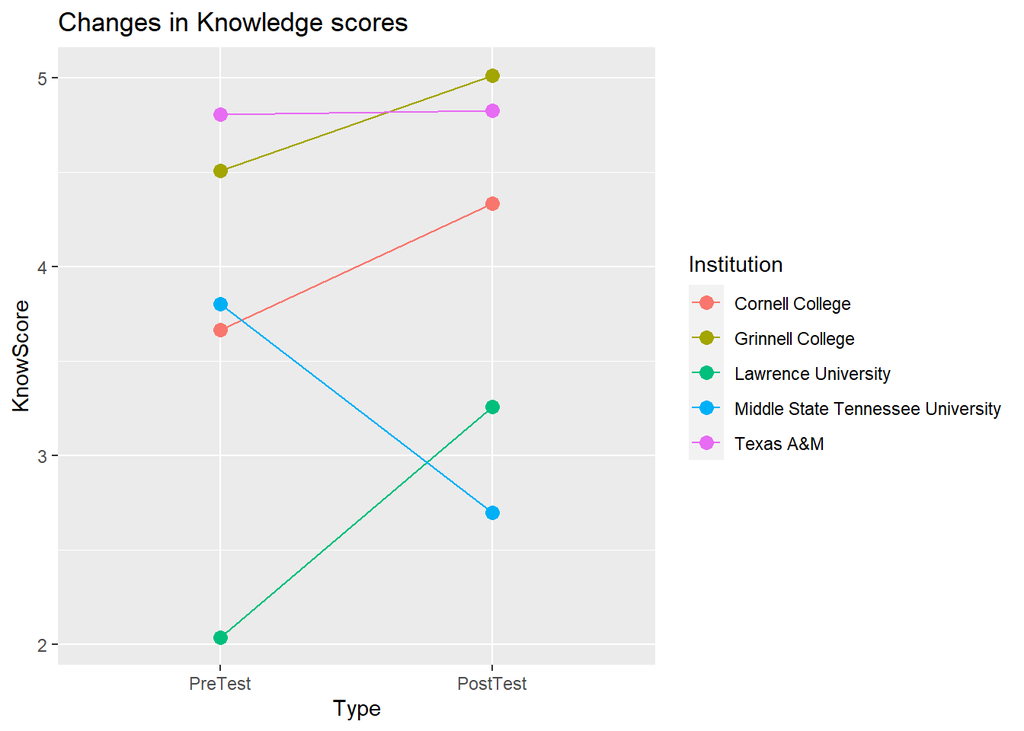

```r
dfGrin = filter(NewData, Institution1 == "Grinnell College")
dfCorn = filter(NewData, Institution1 == "Cornell College")
dfTex = filter(NewData, Institution1 == "Texas A&M")
dfMTSU = filter(NewData, Institution1 == "Middle Tennessee State University")
dfLaw = filter(NewData, Institution1 == "Lawrence University")
knowGrinPre = mean(dfGrin$Knowled1)
knowGrinPost = mean(dfGrin$Knowled2)
knowCornPre = mean(dfCorn$Knowled1)
knowCornPost = mean(dfCorn$Knowled2)
knowTexPre = mean(dfTex$Knowled1)
knowTexPost = mean(dfTex$Knowled2)
knowMTSUPre = mean(dfMTSU$Knowled1)
knowMTSUPost = mean(dfMTSU$Knowled2)
knowLawPre = mean(dfLaw$Knowled1)
knowLawPost = mean(dfLaw$Knowled2)


Institution = c("Grinnell College", "Grinnell College", "Cornell College", "Cornell College", "Texas A&M","Texas A&M", "Middle State Tennessee University", "Middle State Tennessee University", "Lawrence University", "Lawrence University")
Type = c("PreTest", "PostTest", "PreTest", "PostTest", "PreTest", "PostTest", "PreTest", "PostTest", "PreTest", "PostTest")
KnowScore = c(knowGrinPre, knowGrinPost, knowCornPre, knowCornPost, knowTexPre, knowTexPost, knowMTSUPre, knowMTSUPost, knowLawPre, knowLawPost)

dfAllKnow = data.frame(Institution, KnowScore, Type)
dfAllKnow$Type <- factor(dfAllKnow$Type, levels = c("PreTest", "PostTest"))


ggplot(dfAllKnow, aes(x = Type, y = KnowScore, colour = Institution, group = Institution)) +
  geom_line() +
  geom_point(size = 3) +
  labs(title = "Changes in Knowledge scores", ylab = "Knowledge score")
```

#visualizations for attitude comparing pre and post for each institution

```r
dfGrinAtt = filter(NewData, Institution1 == "Grinnell College")
dfCornAtt = filter(NewData, Institution1 == "Cornell College")
dfTexAtt = filter(NewData, Institution1 == "Texas A&M")
dfMTSUAtt = filter(NewData, Institution1 == "Middle Tennessee State University")
dfLawAtt = filter(NewData, Institution1 == "Lawrence University")
attGrinPre = mean(dfGrinAtt$Attd1)
attGrinPost = mean(dfGrinAtt$Attd2)
attCornPre = mean(dfCornAtt$Attd1)
attCornPost = mean(dfCornAtt$Attd2)
attTexPre = mean(dfTexAtt$Attd1)
attTexPost = mean(dfTexAtt$Attd2)
attMTSUPre = mean(dfMTSUAtt$Attd1)
attMTSUPost = mean(dfMTSUAtt$Attd2)
attLawPre = mean(dfLawAtt$Attd1)
attLawPost = mean(dfLawAtt$Attd2)

Institution = c("Grinnell College", "Grinnell College", "Cornell College", "Cornell College", "Texas A&M","Texas A&M", "Middle State Tennessee University", "Middle State Tennessee University", "Lawrence University", "Lawrence University")
preorpost = c("PreTest", "PostTest", "PreTest", "PostTest", "PreTest", "PostTest", "PreTest", "PostTest", "PreTest", "PostTest")
AttScore = c(attGrinPre, attGrinPost, attCornPre, attCornPost, attTexPre, attTexPost, attMTSUPre, attMTSUPost, attLawPre, attLawPost)

dfAllAtt = data.frame(Institution, AttScore, preorpost)
dfAllAtt$preorpost <- factor(dfAllAtt$preorpost, levels = c("PreTest", "PostTest"))
print (dfAllAtt)
```

```
##                          Institution AttScore preorpost
## 1                   Grinnell College 2.764706   PreTest
## 2                   Grinnell College 2.225490  PostTest
## 3                    Cornell College 2.380952   PreTest
## 4                    Cornell College 1.714286  PostTest
## 5                          Texas A&M 2.961538   PreTest
## 6                          Texas A&M 2.423077  PostTest
## 7  Middle State Tennessee University 1.799145   PreTest
## 8  Middle State Tennessee University 1.025641  PostTest
## 9                Lawrence University 1.685185   PreTest
## 10               Lawrence University 1.185185  PostTest
```

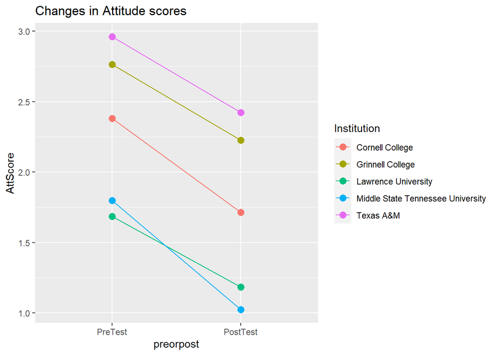

```r
ggplot(dfAllAtt, aes(x = preorpost, y = AttScore, colour = Institution, group = Institution)) +
  geom_line() +
  geom_point(size = 3) +
  labs(title = "Changes in Attitude scores")
```

```r
# library(dplyr)
# colleges_type <- group_by(NewData, Institution1, Type)
# summarize(colleges_type,
#           mean = mean(Knowled1))
```

#verification of Score matching Knowledge columns. Doesn’t quite match because of Lawrence?

```r
library(mosaic)
tmp = NewData %>% filter(Institution1 == "Grinnell College")

tmp$Score[is.na(tmp$Score)] = 0

# paste("Mean for pre Score: " , favstats(tmp$Score))
# paste("Mean for post Score: " ,favstats(tmp$Score))
# paste("Mean for pre Know: " , favstats(tmp$Knowled1))
# paste("Mean for post Know: " ,favstats(tmp$Knowled2))

print(sum(tmp$Score))
```

```
## [1] 3476
```

```r
print(sum(tmp$Knowled1) /2 + sum(tmp$Knowled2)/2)
```

```
## [1] 1943
```

```r
#identify rows where it doesn't match. check if grinnell works.

# write.csv(tmp, "tmp.csv")
```

#why is attitude scores lowering?

#which questions are making a difference in attitudes. where is the change happening? tables? boxplots? summary?

#In the table, meanatt1.1 means mean score on question1 pretest and meanatt2.1 means mean score on question1 posttest. #“q1” is “I would prefer to avoid courses that use statistics1”, #“q2” is “Statistics will help me better understand studies that I read or hear about1”, #“q3” is “Statistics requires critical thinking that helps researchers make better decisions based upon data1”, #“q4” is “Real problems often have obstacles that could be approached in multiple ways1”, #“q5” is “This course will be useful for me in the future1”, #“q6” is “There really is no difference between statistics courses and math courses1”

```r
NewData2 = NewData

attmeans = group_by(NewData2, Institution1)
summarize(attmeans,
          meanatt1.1 = mean(att1.1),
          meanatt2.1 = mean(att2.1),
          meanatt1.2 = mean(att1.2),
          meanatt2.2 = mean(att2.2),
          meanatt1.3 = mean(att1.3),
          meanatt2.3 = mean(att2.3),
          meanatt1.4 = mean(att1.4),
          meanatt2.4 = mean(att2.4),
          meanatt1.5 = mean(att1.5),
          meanatt2.5 = mean(att2.5),
          meanatt1.6 = mean(att1.6),
          meanatt2.6 = mean(att2.6))
```

```
## # A tibble: 6 x 13
##   Institution1 meanatt1.1 meanatt2.1 meanatt1.2 meanatt2.2 meanatt1.3 meanatt2.3
##   <chr>             <dbl>      <dbl>      <dbl>      <dbl>      <dbl>      <dbl>
## 1 Cornell Col~     0.0952     0.0952      0.905      0.667     -0.857     -0.810
## 2 Grinnell Co~     0.466      0.284       0.858      0.735     -0.848     -0.735
## 3 Lawrence Un~    -0.204     -0.167       0.815      0.685     -0.907     -0.704
## 4 Middle Tenn~     0.132      0.115       0.641      0.376     -0.846     -0.483
## 5 Texas A&M        0.538      0.462       0.885      0.712     -0.923     -0.692
## 6 <NA>             0          0           0          0          0          0
## # ... with 6 more variables: meanatt1.4 <dbl>, meanatt2.4 <dbl>,
## #   meanatt1.5 <dbl>, meanatt2.5 <dbl>, meanatt1.6 <dbl>, meanatt2.6 <dbl>
```

#Table for PriorStat courses boxplot

```r
Grin = NewData %>% filter(Institution1 == "Grinnell College")
Corn = NewData %>% filter(Institution1 == "Cornell College")
Tex = NewData %>% filter(Institution1 == "Texas A&M")
MTSU = NewData %>% filter(Institution1 == "Middle Tennessee State University")
Law = NewData %>% filter(Institution1 == "Lawrence University")


priorstatgroup1 = group_by(Grin, Institution1, PriorStats1, Type, PrePost)
summarise(priorstatgroup1,
        Gn = n(),
        Gmean = mean(Score, na.rm = TRUE),
        Gsd = sd(Score, na.rm= TRUE))
```

```
## can override using the `.groups` argument.
```

```
## # A tibble: 16 x 7
## # Groups:   Institution1, PriorStats1, Type [8]
##    Institution1     PriorStats1 Type    PrePost     Gn Gmean   Gsd
##    <chr>                  <dbl> <chr>   <fct>    <int> <dbl> <dbl>
##  1 Grinnell College           0 Handout PreTest     68  7.37  2.91
##  2 Grinnell College           0 Handout PostTest    68  9.61  2.79
##  3 Grinnell College           0 Website PreTest     55  7.90  2.31
##  4 Grinnell College           0 Website PostTest    55 10.9   2.58
##  5 Grinnell College           1 Handout PreTest     33 10.0   2.07
##  6 Grinnell College           1 Handout PostTest    33 10.8   3.06
##  7 Grinnell College           1 Website PreTest     29  9.31  2.49
##  8 Grinnell College           1 Website PostTest    29 11.2   1.64
##  9 Grinnell College           2 Handout PreTest      3 12.7   1.53
## 10 Grinnell College           2 Handout PostTest     3 13     1
## 11 Grinnell College           2 Website PreTest      9 11.1   1.90
## 12 Grinnell College           2 Website PostTest     9 11.8   1.04
## 13 Grinnell College           3 Handout PreTest      2 12     1.41
## 14 Grinnell College           3 Handout PostTest     2 13     1.41
## 15 Grinnell College           3 Website PreTest      5 10.6   1.67
## 16 Grinnell College           3 Website PostTest     5 12.2   1.30
```

```r
priorstatgroup2 = group_by(Corn, Institution1, PriorStats1, Type, PrePost)
summarise(priorstatgroup2,
        Cn = n(),
        Cmean = mean(Score, na.rm = TRUE),
        Csd = sd(Score, na.rm= TRUE))
```

```
## can override using the `.groups` argument.
```

```
## # A tibble: 4 x 7
## # Groups:   Institution1, PriorStats1, Type [2]
##   Institution1    PriorStats1 Type    PrePost     Cn Cmean   Csd
##   <chr>                 <dbl> <chr>   <fct>    <int> <dbl> <dbl>
## 1 Cornell College           0 Website PreTest     16  6.25  2.11
## 2 Cornell College           0 Website PostTest    16  8.21  2.33
## 3 Cornell College           1 Website PreTest      5  6.2   1.30
## 4 Cornell College           1 Website PostTest     5  8     3.74
```

```r
priorstatgroup3 = group_by(Tex, Institution1, PriorStats1, Type, PrePost)
summarise(priorstatgroup3,
        Tn = n(),
        Tmean = mean(Score, na.rm = TRUE),
        Tsd = sd(Score, na.rm= TRUE))
```

```
## can override using the `.groups` argument.
```

```
## # A tibble: 8 x 7
## # Groups:   Institution1, PriorStats1, Type [4]
##   Institution1 PriorStats1 Type    PrePost     Tn Tmean    Tsd
##   <chr>              <dbl> <chr>   <fct>    <int> <dbl>  <dbl>
## 1 Texas A&M              0 Website PreTest     11  8.82  2.14
## 2 Texas A&M              0 Website PostTest    11  8.5   2.64
## 3 Texas A&M              1 Website PreTest     29  7.62  2.77
## 4 Texas A&M              1 Website PostTest    29  9.62  2.36
## 5 Texas A&M              2 Website PreTest     10 10.1   1.91
## 6 Texas A&M              2 Website PostTest    10 10.6   2.01
## 7 Texas A&M              3 Website PreTest      2 11.5   0.707
## 8 Texas A&M              3 Website PostTest     2 12    NA
```

```r
priorstatgroup4 = group_by(MTSU, Institution1, PriorStats1, Type, PrePost)
summarise(priorstatgroup4,
        Mn = n(),
        Mmean = mean(Score, na.rm = TRUE),
        Msd = sd(Score, na.rm= TRUE))
```

```
## can override using the `.groups` argument.
```

```
## # A tibble: 16 x 7
## # Groups:   Institution1, PriorStats1, Type [8]
##    Institution1                     PriorStats1 Type  PrePost    Mn  Mmean   Msd
##    <chr>                                  <dbl> <chr> <fct>   <int>  <dbl> <dbl>
##  1 Middle Tennessee State Universi~           0 Hand~ PreTest    92   6.48  2.40
##  2 Middle Tennessee State Universi~           0 Hand~ PostTe~    92   7.03  2.43
##  3 Middle Tennessee State Universi~           0 Webs~ PreTest    50   5.04  2.85
##  4 Middle Tennessee State Universi~           0 Webs~ PostTe~    50   7.05  2.50
##  5 Middle Tennessee State Universi~           1 Hand~ PreTest    51   6.84  2.40
##  6 Middle Tennessee State Universi~           1 Hand~ PostTe~    51   7.70  2.90
##  7 Middle Tennessee State Universi~           1 Webs~ PreTest    29   6.69  2.80
##  8 Middle Tennessee State Universi~           1 Webs~ PostTe~    29   8.45  2.07
##  9 Middle Tennessee State Universi~           2 Hand~ PreTest     5   7     2.65
## 10 Middle Tennessee State Universi~           2 Hand~ PostTe~     5   6.4   1.82
## 11 Middle Tennessee State Universi~           2 Webs~ PreTest     3   6.67  2.52
## 12 Middle Tennessee State Universi~           2 Webs~ PostTe~     3 NaN    NA
## 13 Middle Tennessee State Universi~           3 Hand~ PreTest     3  11.7   2.08
## 14 Middle Tennessee State Universi~           3 Hand~ PostTe~     3  11     1
## 15 Middle Tennessee State Universi~           3 Webs~ PreTest     1   5    NA
## 16 Middle Tennessee State Universi~           3 Webs~ PostTe~     1   8    NA
```

```r
priorstatgroup5 = group_by(Law, Institution1, PriorStats1, Type, PrePost)
summarise(priorstatgroup5,
        Ln = n(),
        Lmean = mean(Score, na.rm = TRUE),
        Lsd = sd(Score, na.rm= TRUE))
```

```
## can override using the `.groups` argument.
```

```
## # A tibble: 8 x 7
## # Groups:   Institution1, PriorStats1, Type [4]
##   Institution1        PriorStats1 Type    PrePost     Ln  Lmean   Lsd
##   <chr>                     <dbl> <chr>   <fct>    <int>  <dbl> <dbl>
## 1 Lawrence University           0 Handout PreTest     18   7.06  2.71
## 2 Lawrence University           0 Handout PostTest    18   9.11  4.68
## 3 Lawrence University           0 Website PreTest     23 NaN    NA
## 4 Lawrence University           0 Website PostTest    23 NaN    NA
## 5 Lawrence University           1 Handout PreTest      7   7.71  2.69
## 6 Lawrence University           1 Handout PostTest     7  10    NA
## 7 Lawrence University           1 Website PreTest      6 NaN    NA
## 8 Lawrence University           1 Website PostTest     6 NaN    NA
```